# Lab2: Reproducible publishing and literate programming with Quarto

Author

Material adapted from Charlotte Soneson

Published

September 7, 2024

# Quarto and literate programming

In this lab you will learn the basics of literate programming and to use the literate programming and manuscript editing system [Quarto](https://quarto.org/). Quarto enables you to produce PDF documents (manuscripts) just as you would do in $\LaTeX$, but also HTML pages—such as the one you are currentl reading—and whole webpages. It even exports to Word-docx format.

## What is literate programming?

The term ‘[literate programming](http://www.literateprogramming.com/)’ was introduced by Donald Knuth in 1984. It refers to a programming paradigm where in one single source file you have:

- parts of explanation of the analysis in natural language (such as English)
- interspersed with **chunks** of executable source code.

This single source file is then used to create both machine executable **code** (effectively, extracting the code chunks) and a comprehensive human-readable report containing both the **natural language text** and the **results** of running the code. A recent [publication](https://academic.oup.com/bib/article/24/6/bbad375/7326135) by Ziemann et al. considers literate programming one of the five pillars of reproducible computational research:

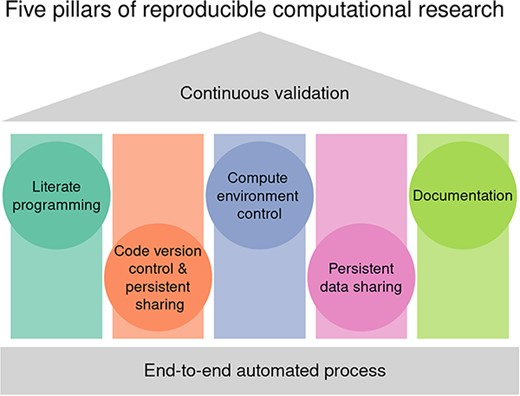

Some of the advantages of using literate programming are:

- since the report contains both the code and the output, we know precisely **which code was executed to generate a specific result** (compare this to copy-pasting your figures from the RStudio viewer into a Word document), and the text and results are arranged in a logical and consistent way. Circumventing the copy-pasting of results into reports also saves time.
- it makes it easy to provide extensive **documentation and explanations of the code**
- it provides **built-in checks** that the given code *actually runs* - if not, no output report is generated.

Example of literate programming environment are “Rmarkdown” (R) and “Jupyter notebook” (python)

# What is R Markdown?

R Markdown lets you write dynamic, reproducible documents in R (actually, it can also contain code in other languages like python or bash!).

- An R Markdown document can contain *regular text* as well as *code chunks*, *equations* and *images*.
- The document can be rendered into many *different output formats*, such as html, pdf, Microsoft Word, websites, and slideshows (for the latter, check out [xaringan](https://slides.yihui.org/xaringan/#1)).
- To install R Markdown you need to install the specific packages, refer to Lab1.0_setup.html

# What is Quarto?

- [Quarto](https://quarto.org) is an open-source publishing system built on markdown. It is developed and maintained by Posit.
- Quarto can be thought of as “next generation” R Markdown, combining what was previously spread across many packages (including `rmarkdown`, `bookdown`, and `xaringan`) into one system.
- Quarto is fundamentally multi-lingual, for example it can be used to write python code without requiring R to be present (R Markdown can also contain python code, but R needs to be present in order to compile the report).
- For a more detailed overview, see e.g. [the Quarto FAQ](https://quarto.org/docs/faq/rmarkdown.html#quarto-sounds-similar-to-r-markdown.-what-is-the-difference-and-why-create-a-new-project) or [this blog post](https://yihui.org/en/2022/04/quarto-r-markdown/).

##### Quarto and R Markdown

- R Markdown and Quarto are very similar in terms of the syntax; in many cases simply changing the file extension from `.Rmd` to `.qmd` or vice versa will give a valid file.
- In this workshop, we will use Quarto, but most of the basics that we are going to cover works perfectly fine also with R Markdown.
- We will use R and [RStudio](https://posit.co/products/open-source/rstudio/) (in case you are interested you can checkout [here](https://bioconductor.github.io/CSAMA-labs/quarto-intro/quarto.html) the corresponding steps to use Quarto in [Visual Studio Code](https://code.visualstudio.com/))

# Creating a .qmd file in RStudio

Let’s create our first Quarto document (`.qmd` file) in RStudio.

- Click on `New File`, and select `Quarto Document` (or, equivalently, go via the menu `File` -> `New File` -> `Quarto Document`).

[figure not shown]

- In the dialog that comes up, you give the document a “Title” and type your name into the “Author” field.
- You can select the default output format, for now, let’s select “HTML” as the output format (this can be changed later). Note that generating pdf or Word output requires additional software to be available on your system.

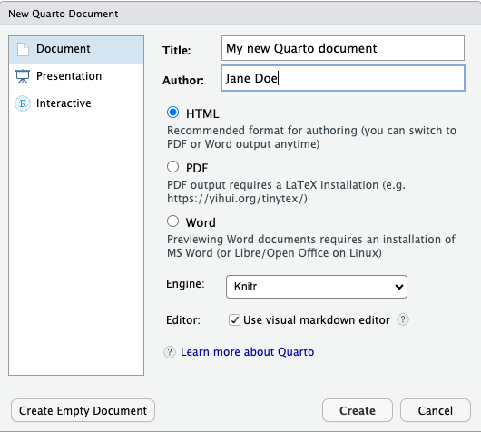

- Click “Create”, your first Quarto document will open in the RStudio IDE, in the scripts and files panel.
- Before we look at the content, **save** the document to disk: either by clicking on the `save` button (the floppy disk at the top of the document) or by going via `File` -> `Save` - here, we will use the name `qmd-example.qmd`.

# Rendering the document

To render a document means to go from the `.qmd` format to create a new file in your final format - i.e. `.html`, `.pdf`, `.doc` etc.  
There are several ways to do it, in RStudio

- one way is to click on the button above the document (or use the keyboard shortcut `Ctrl`+`Shift`+`K`, or `Cmd`+`Shift`+`K` on macOS).
- another option is to type the following in the R console (assuming that the `quarto` package is installed and that the `.qmd` file is saved as `qmd-example.qmd` in the current working directory):

```r
quarto::quarto_render("qmd-example.qmd")
```

Either of these options will render the document in a new R session. The figure below illustrates what happens ‘under the hood’ when a document is rendered:

[figure not shown]

Source: https://quarto.org/docs/get-started/hello/rstudio.html

More settings related to the rendering can be found by clicking on the little gear next to the Render button:

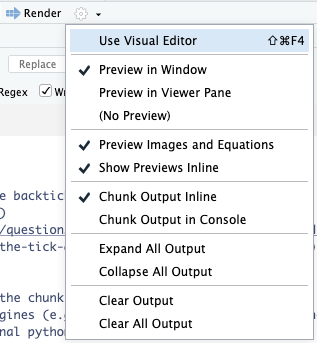

**Rendering an R Markdown document**

To use create an R Markdown document you can repeat the same steps as for the Quarto document, selecting `R Makrdown` as new file.

To render an R Markdown document, you can click the `Knit` button in RStudio, or type (assuming `rmarkdown` package is install)

```r
rmarkdown::render("rmd-example.rmd")
```

However, in this case there is an important difference between the two ways of rendering the document: clicking on the `Knit` button will render the document in a new R session, while `rmarkdown::render()` will by default execute the code in the document in the “parent environment” (the current active R session).

For now, let’s click on the `Render` button to generate an HTML file from our `.qmd` document.

# Quarto doc structure

Now that we’ve tried the process of generating the output file, let’s take a look at the structure of the `.qmd` file.

## 1. The YAML header

```
---
title: "My first Quarto document"
author: "Jane Doe"
format: html
---
```

If we want to change the output format, this can be done in the YAML header (i.e., there’s no need to create a new document from scratch), any idea on how to do it?

**exercise**

Try to change the output format from HTML to PDF.

**Solution - format to pdf**

For example, if we want a PDF file rather than an HTML file, we change the last line in the YAML header to:

```
format: pdf
```

Now try to render. Did it work? Remember you need to install some additional software to render to PDF, specifically LaTex (go to the Lab1.0_setup.html if it didn’t work or ask the TAs) .

Let’s start adding some more configuration:  
We can configure many aspects of our document via the YAML fields. The available fields depend to some extent on the selected format. [This website](https://quarto.org/docs/reference/formats/html.html) lists the options available for HTML files.

- In our example document, let’s add a *table of contents* (toc) and change the *theme*. You can find a list of available themes [here](https://www.datadreaming.org/posts/2018-04-11-r-markdown-theme-gallery/2018-04-11-r-markdown-theme-gallery.html).  
  Under the format section, specify the configuration for the html (note the **indentation** under `format` - this is important for correct parsing of the YAML):

```
format:
    html:
        toc: true
        theme: cosmo
```

Now render, can you see what changed?

- We will also add a line to make the HTML file *self-contained* (`embed-resources: true`). A self-contained HTML file is **larger**, but can be **shared or moved without external dependencies**. Without this line, any external dependencies of the HTML file (images, style sheets, etc) will be placed in a separate folder, which must be distributed along with the **HTML file** for proper rendering. Our YAML header will now look something like this:

```
---
title: "My first Quarto document"
author: "Jane Doe"
format:
    html:
        toc: true
        theme: cosmo
        embed-resources: true
---
```

**Multiple formats**:

- For example, say we would like the possibility to render the document into html format AND also into PDF format. We would like to have a **table of content in both cases.** So far, the options that we specified are applied specifically to html output format.  
  If we want to apply the specified options across any output format, we can also **define them on the top level**, rather than under the specific format.  
  This could be as follows:

```
---
title: "My first Quarto document"
author: "Jane Doe"
toc: true
format:
    html:
        theme: cosmo
        embed-resources: true
    pdf: default
---
```

Note that table-of-contents option `toc: true` is now outside the format option

By default, the format that is specified first in the YAML will be used.

**Add the date**:  
An essential option is the `date`, this allows you to keep track on when the document has been created.  
There are different ways to do include the date in the header.  
Can you think of how to add the date of today without looking at the solutions?

**Exercise**

Add a date to the YAML header. See [here](https://quarto.org/docs/reference/dates) for information about how to specify dates in Quarto.

**Solution - fixed date**

```
---
title: "My first Quarto document"
author: "Jane Doe"
date: "2024-06-11"
date-format: "long"
format:
    html:
        toc: true
        theme: cosmo
        embed-resources: true
---
```

**Solution - using the date when the document is rendered**

With the two following solutions, we can add a flexible date to our document. This means that every time that we render our document, the date is updated. This helps you keep track on when the final document has been produced.

1. using R code In R you can get the date using `Sys.Date()`, and you can recall this in the YAML header as follows:

```
---
title: "My first Quarto document"
author: "Jane Doe"
date: "`r Sys.Date()`"
date-format: "long"
format:
    html:
        toc: true
        theme: cosmo
        embed-resources: true
---
```

2. using `today` quarto keyword (does not work in R Markdown)

```
---
title: "My first Quarto document"
author: "Jane Doe"
date: today
date-format: "long"
format:
    html:
        toc: true
        theme: cosmo
        embed-resources: true
---
```

## 2. The body of the document

Below the YAML header, the rest of the `.qmd` document consists of a mix of regular text and code chunks. The text is formatted according to [`markdown` syntax](https://www.rstudio.com/wp-content/uploads/2015/03/rmarkdown-reference.pdf) (see also [this page](https://www.markdownguide.org/basic-syntax/)).

#### Headers

For example headers (of different levels) are generated by prepending (different numbers of) hash symbols (`#`) to the header text:

```
# Header 1
## Header 2
### Header 3
```

Note that a line will actually be a header only if there is a blank line above. For example:

```
Some text here

# this will be a header of level 1
Some other text here
## this will not be a header
```

#### New lines

Very important: a line break in the `.qmd` document does not correspond to a line break on the output file. To do a new line, you can

- write `<br>` add the end of your line

```
method for new line: <br>
here is a new line
```

Will render:  
*method for new line:*  
*here is a new line*

- to do a change of paragraph, you can insert a blank line

```
method for new paragraph:

here is a new line in a new paragraph
```

Will render:  
*method for new paragraph:*

*here is a new line in a new paragraph*

#### **Bold**, *italic*

- **Bold** **text** is obtained by adding `__` or `**` to each side of the text, and
- *italic* *text* is obtained by adding `_` or `*` to each side of the text.

**Tip**

To convert an entire word or multiple ones in **bold** or *italic*, highlight that word and type *, look at what happens.  
Try it out with the parentheses (, [, { and the back tick `

#### Code chunks

Code chunks are generated with the following syntax:

````markdown
```{r}
x <- 1 + 1
```
````

- The `{r}` part indicates that the chunk contains R code. It is possible to use other engines (e.g., python or bash) by replacing the `r` in the chunk header (note that *additional packages*, as well as a functional python installation, may be required to, e.g., execute python code).
- Rather than explicitly typing the code chunk, we can use the keyboard shortcut `Ctrl`+`Alt`+`I` (or `Cmd`+`Option`+`I` on macOS) in RStudio. It will automatically add an R code chunk on the next line.
- It is also useful to know that we can **directly execute a line** in a code chunk in the `.qmd` file by placing the cursor on the line and pressing `Ctrl`+`Enter` (or `Cmd`+`Enter` on macOS).
- **A whole chunk** can be executed by clicking on the little green arrow in the top right corner of the chunk. The grey arrow executes all chunks preceding the current chunk.

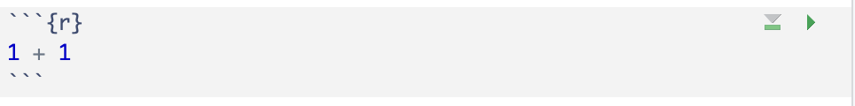

**Tip**

Depending on your keyboard you will find the backtick ` in different position  
On a Windows QWERTY keyboard:

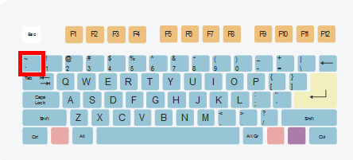

Source: https://superuser.com/questions/254076/how-do-i-type-the-tick-and-backtick-characters-on-windows

On a Mac QWERTY keyboard:

[figure not shown]

We can also include inline R code, enclosed in single backticks: `` `{r} x + 1` `` (as for the code chunks, we can use different code engines here as well). This is useful e.g. if we want to refer to values of specific variables directly in the text. A frequent use of this syntax can be seen in the YAML header above - see how the current date was obtained by executing the R function `Sys.Date()`.

**Exercise**

Let’s now practice what we just learned. In your example `.qmd` document, add a suitable header and a code chunk where you print the first six rows of the built-in `iris` dataset. Below the code chunk, add a sentence where you include the number of observations (rows) in the `iris` dataset.

**Tips**

- the `iris` dataset already exists in R, try to type `head(iris)` on the console, what is the output?
- render in html, and if you can to pdf too

**Possible solution - try it first yourself**

````
---
title: "My first Quarto document"
author: "Jane Doe"
toc: true
format:
   html:
       theme: cosmo
       embed-resources: true
   pdf: default
---


# Analysis of iris dataset


```{r}
print(head(iris))
```


These are the first 6 rows of the `iris` dataset
that contains a total of `{r} nrow(iris)` observations
````

# Customizing code chunks

In addition to the language indicator, there are many other ways of customizing code chunks with so called ‘**chunk options**’.  
Chunk options are specified inside the chunk, preceded by `#|`.

- For example, we can decide whether the code should be evaluated at all (`eval`)
- whether the code should be shown or hidden in the final report (`echo`)
- and the size of any figures generated by the code.  
  We can also add captions and alt-text for any displayed figures, for increased accessibility.

The following chunk will be printed `echo: true`, but not executed `eval: false`:

````markdown
```{r}
#| echo: true
#| eval: false

1 + 1
```
````

For additional controls related to chunk execution, see [this page](https://quarto.org/docs/computations/execution-options.html).

- The options can also be set globally in the YAML header, under the `execute` directive. Specifications in a given chunk will override the global settings.
- It is often useful to assign `labels` to the chunks. This makes it easier to navigate the document and find the source of any errors, and additionally means that any output figures generated in the document will be named according to the chunk where they were generated.  
  In RStudio, you can navigate between sections and chunks in the lower left corner of the editor panel:

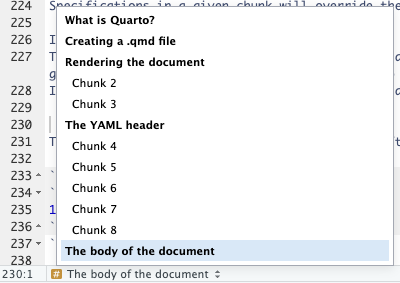

To label a chunk, add a suitable name as an option:

````markdown
```{r}
#| label: addition_chunk

1 + 1
```
````

**Exercise**

Let’s now practice what we just learned. In your example `.qmd` document,

1. print the first 6 rows hiding the chunk that generates the output
2. create a second chunk in which you print the species present in the dataset
3. create a third chunk in which you output the summary of sepal measurements: lenght and width
4. set chunk options so that in the final report you show the code only for the last chunk

**Possible solution - try it first yourself**

look at the `qmd-example.qmd` in the folder of this lab

# Markdown editing modes

In ‘Visual’ mode, we can edit the document in a perhaps more intuitive way (or, at least, in a way that is more similar to the final rendered version). For example, adding headers can now be done by selecting the desired header level from a dropdown menu. We can swap between the two editing modes at any time. This can also be helpful in order to learn the markdown syntax for specific formatting options.

# Parameterized reports

Sometimes, we have a template `.qmd` file from which we would like to generate multiple output files, each with a different value of a given parameter. Instead of generating a separate `.qmd` file for each of these parameter values, we can make use of so called [*parameterized reports*](https://quarto.org/docs/computations/parameters.html). To parameterize your `.qmd` file, add a section in the YAML header defining the parameters that will be used, and provide a default value:

```
---
title: "My first Quarto document"
author: "Jane Doe"
date: "`r Sys.Date()`"
date-format: "long"
format:
    html:
        toc: true
        theme: cosmo
        embed-resources: true
params:
    species: "setosa"
---
```

You can then use the parameter anywhere in the document via the R syntax `params$species`. Any number of parameters can be specified in this way. Now, if the document is rendered via the `Render` button, the default value of each parameter will be used. To change the value, use the `quarto_render()` function from the `quarto` R package and specify the desired parameter values via the `execute_params` argument:

```r
quarto::quarto_render("qmd-example.qmd",
                      execute_params = list(species = "virginica"))
```

We can also set the name of the output file (we may want this to reflect the parameter value):

```r
quarto::quarto_render("qmd-example.qmd",
                      execute_params = list(species = "virginica"),
                      output_file = "virginica_report.html")
```

**Exercise**

Take your `qmd-example.qmd`, now make the code chunk about the summary of sepal measurements specific for a species.  
Output the reports for each one of the species in a specific file.

**Possible solution - try it first yourself**

1. Add the to the header

```
params:
    species: "setosa"
```

2. Change the chunk about the summary of measurement using `params$species`:

````markdown
Summary of the measurements of sepal length and width in the species **`{r} print(params$species)`**:

```{r}
#| echo: true
#| label: summary_species
summary(iris[iris$Species == params$species, "Sepal.Length"])
summary(iris[iris$Species == params$species, "Sepal.Width"])
```
````

3. output the reports, repeat the command by changing the name of the species

```r
quarto::quarto_render("qmd-example.qmd",
                      execute_params = list(species = "setosa"),
                      output_file = "setosa_report.html")
```

# Session info

In order to keep a record of the package versions used to generate a given output file, it is useful to include a code chunk providing the session information in the end of every `.qmd` file. Add the following to your example `.qmd`:

````markdown
```{r}
sessionInfo()
```
````

As a bonus, with a bit of HTML, we can even make it collapsible, to take less space but still be available if requested.

````markdown
<details>
<summary><b>
Session info
</b></summary>
```{r}
sessionInfo()
```
</details>
````

**Exercise**

Try it out! Add the lines above to your `qmd-example.qmd` and see how it looks like

# Images

Images can be included in `.qmd` files using the following syntax:

```
![](path/to/image.png)
```

Alternatively, we can use `knitr`:

````markdown
```{r}
knitr::include_graphics("path/to/image.png")
```
````

Or directly HTML:

```
<img src="path/to/image.png" width="90%"/>
```

# Assembling figure panels within R

Using the workflow described above, we have a way to reproducibly generate figure panels starting from a suitably processed input data file. Remember the figure you just created in the previous lab, we used the [`patchwork`](https://patchwork.data-imaginist.com/) R package. This is not the only R package that allows this type of workflow - you can also have a look at [`cowplot`](https://cran.r-project.org/web/packages/cowplot/vignettes/introduction.html). In python, there is a corresponding package [`patchworklib`](https://pypi.org/project/patchworklib/).

The idea behind these packages is that we create the individual figure panels as usual, and the use the capabilities of (e.g.) `patchwork` to assemble the panels in a suitable configuration.

We can also include **pre-generated image files** (e.g., in png format). This can be useful if we want to generate figures containing panels with schematics or other types of images that are not generated in R. One way to get such files into R and a format compatible with `patchwork` or `cowplot` is to use the `ggdraw()` and `draw_image()` functions from the `cowplot` package.

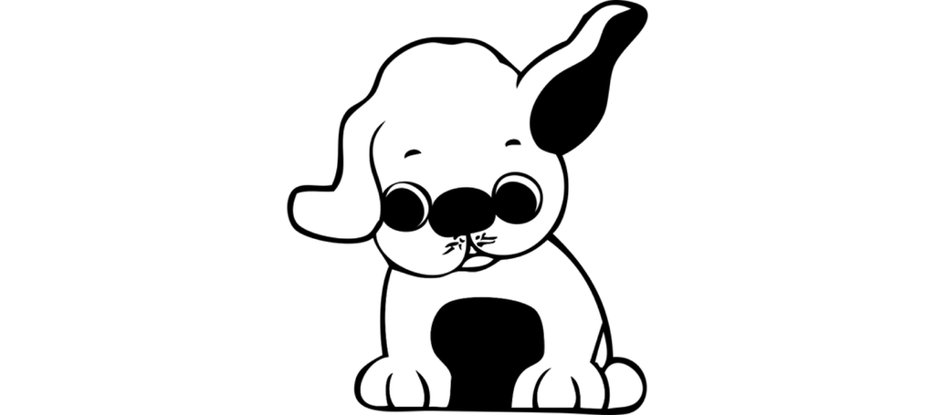

```r
puppy <- cowplot::ggdraw() +
    cowplot::draw_image("https://publicdomainvectors.org/photos/johnny_automatic_puppy.png")
puppy
```

Many more examples and guidance can be found on the [patchwork website](https://patchwork.data-imaginist.com/).

# Reproducible publishing with journal templates

So far, we have seen how we can write reports and generate complete figures in a reproducible way. This type of reports could, for example, be used as supplementary material for a manuscript. To generate the actual manuscript file, we would still need to paste the results and the generated figures into the Word document that will be submitted to the journal. However, Quarto also provides [journal templates](https://quarto.org/docs/journals/) for several journals, which means that we can directly write our paper using literate programming, and submit the resulting Word/LaTeX/pdf file to the journal. If your favorite journal does not already have a template, you can also create your own. The setup makes it easy to change between different journal styles, still using the same underlying source file. This approach works well for “not-too-computational” manuscripts, **where all computations can be run in a single file, and are sufficiently quick** that it is not a problem to rerun them each time anything in the manuscript changes.

Let’s try this out - we’ll create an example journal article, using the style from the PLOS family of journals. Typing the following code into a terminal window will initialize a new `.qmd` file following this journal template style:

```bash
quarto use template quarto-journals/plos
```

The resulting file can then be edited and expanded upon like any other Quarto file. If you just want to install the journal format extension (without creating a new document), e.g. to use it in an existing document, you can do that by running the following code from within the target directory:

```bash
quarto add quarto-journals/plos
```

# Quarto Manuscripts

An even more comprehensive toolbox for publishing manuscripts is provided by the *Quarto Manuscripts* framework. Here, each Quarto manuscript is its own [Quarto project](https://quarto.org/docs/projects/quarto-projects.html) (not just a single file). The manuscript will be rendered in multiple formats, which can all be accessed via a generated website. Separate notebooks can also be used as a source of content and computations. Thus, this approach, while more complex than what we have seen before, is really aimed at producing fully reproducible manuscripts for projects involving lots of computation, perhaps in different languages, which can not all be re-executed every time the manuscript text changes.

An example can be seen [here](https://notebooks-now.github.io/submission-quarto-full/). To initialize such a manuscript, we have to create a Quarto project. This can be done from the command line as follows:

```bash
quarto create project manuscript my_awesome_manuscript
```

This will create a Quarto project in a new folder named `my_awesome_manuscript`, and you can further choose to open it in either RStudio or Visual Studio Code.

# Final tips

- Always include the session info.
- Avoid hardcoded absolute paths, they will make it impossible for someone else to reproduce your analysis.
- With parameterized reports, it’s helpful to print out the values of the parameters somewhere in the report for reproducibility purposes, as the final report may have been generated from the command line with parameter values different from the default ones contained in the source file.

# Conclusion

In this workshop, we have seen how we can use Quarto to generate reproducible reports containing both text, code and output. Most of the things that have been described can be applied to R Markdown. Of course this is not the only way to make analyses reproducible - done correctly, a regular script can be just as reproducible. One nice aspect of literate programming, however, is that you can be sure that if the document compiles, the code actually works, you will see exactly how each figure was generated, and there is no way to ‘leave out’ or miss any details. With a script, you need some level of trust that this was, in fact, the code that was used to generate the saved figures. In addition, there are many other aspects that are essential for reproducibility that we have not touched upon here, including making all data accessible, and if possible providing a reproducible software environment (for example, using conda environments or docker images).

# Resources

- [RStudio keyboard shortcuts](https://bookdown.org/yihui/rmarkdown-cookbook/rstudio-shortcuts.html)
- [Quarto webpage](https://quarto.org/)
- [Quarto introductory tutorial](https://quarto.org/docs/get-started/hello/rstudio.html)
- [Quarto authoring guide](https://quarto.org/docs/get-started/authoring/rstudio.html)
- [More details about article layout in Quarto](https://quarto.org/docs/authoring/article-layout.html)
- [R Markdown cheat sheet from RStudio](https://www.rstudio.com/wp-content/uploads/2015/02/rmarkdown-cheatsheet.pdf)
- [R Markdown reference guide](https://www.rstudio.com/wp-content/uploads/2015/03/rmarkdown-reference.pdf)
- [R Markdown crash course](https://zsmith27.github.io/rmarkdown_crash-course/index.html)
- [R Markdown website](https://rmarkdown.rstudio.com/)
- [Lessons on R Markdown](https://rmarkdown.rstudio.com/lesson-1.html)
- [R Markdown - the definitive guide](https://bookdown.org/yihui/rmarkdown/)
- [R Markdown cookbook](https://bookdown.org/yihui/rmarkdown-cookbook/)
- [Blog post on Quarto vs Rmarkdown](https://yihui.org/en/2022/04/quarto-r-markdown/#:~:text=For%20R%20users%2C%20Quarto%20uses,implementation%20of%20figure%20cross%2Dreferences.)
- [Quarto/R Markdown - what’s different](https://laderast.github.io/qmd_rmd/#/title-slide)
- [Quarto extensions - journal articles](https://quarto.org/docs/extensions/listing-journals.html)
- [Reproducible manuscripts with Quarto (talk by JJ Allaire)](https://jjallaire.quarto.pub/reproducible-manuscripts-with-quarto/#/title-slide)
- [Quarto webR extension for building interactive websites](https://quarto-webr.thecoatlessprofessor.com/)
- [Hello Quarto! Keynote from rstudio::conf(2022)](https://www.youtube.com/watch?v=p7Hxu4coDl8)
- [Quarto introduction in R4DS book](https://r4ds.hadley.nz/quarto)
- [A Primer on dynamic reporting](https://zenodo.org/records/8354360)
- [Reproducible manuscripts with Quarto (talk by Mine Cetinkaya-Rundel)](https://mine.quarto.pub/manuscripts-conf23/#/title-slide)